**문서 작성법**

By Prof. Seungchul Lee  
http://iai.postech.ac.kr/  
Industrial AI Lab at POSTECH  
최종 수정일 : 2020.03.02

Table of Contents

# 1. MS WORD

```python
%%html
<center><iframe src="https://www.youtube.com/embed/TmRB1362ics?rel=0"
width="560" height="315" frameborder="0" allowfullscreen></iframe></center>
```

[video not shown]

- 우리 연구실은 MS word 로 작성을 기본으로 한다
- 단, 정부과제 또는 협업기관에서 아래한글을 사용할 경우, 아래한글로 작성해야 한다.
- 논문 작성시 MS word 와 Latex 를 사용하는 방법이 있는데,
  - 협업시에는 MS word 가 편하고
  - Latex (https://www.overleaf.com/) 의 가장 큰 장점은 포멧을 신경 쓸 필요가 없고, 수식 작성에 아주 큰 장점이 있다.
- 기본적으로 MS word 로 작성하고, 지도교수가 허락하는 경우에만 Latex 를 사용하세요.
- Google Docs (https://www.google.com/docs/about/)
  - 많은 사람들이 동시에 editing 을 해야 할 경우에는 google docs 을 통해서 포멧 신경쓰지 말고 내용을 먼저 마무리하고
  - 한 사람이 MS word 또는 아래한글로 옮겨서 포멧을 통일 시키는 방법이 효과적이다.
  - 여러 기관과 동시에 논문, 제안서 작업에 유용합니다.
- 논문 작성으로 가정하고 설명
  - 포멧팅이 부수적인 것일 수도 있지만, 리뷰를 할 때 첫인상이기 때문에 중요하다.
  - 포멧팅이 잘되어 있는 문서는 기본적으로 신경을 많이 쓴 논문이라고 생각되어 진다.
  - 논문의 경우 accept 이 되면 원본 워드 파일을 제출하고 출판사에서 전문가가 일괄적으로 포멧팅을 하기 때문에 manuscript 를 제출할 때는 가독성이 높은 방향으로 통일만 하면 된다.
  - Latex 의 경우는 저널마다 template 있기 때문에 편할 수 있다.

# 2. Technical Tips

## 2.1. Copy and Paste

- 가지고 올때 format 이 따라온다.
- paste 를 할때 format 없이 오게 할 수도 있지만,
- 확실하게 하기위해서 가장 선호하는 방법은 notepad 를 거쳐서 오는 것

## 2.2. Font

- 영어는 Times New Roman
- 한글은 한컴바탕을 기본으로 하지만
- 보고서의 경우는 상위 기관이 지정하는 폰트 사용

## 2.3. Styles

- 스타일은 자주 사용하는 포멧을 미리 지정해 두는 것이다.
- 우리 연구실 템플릿에 있는 스타일을 사용한다.
  - Normal
  - Heading 1
  - Heading 2
  - Heading 3
  - Equation
  - Title
  - Reference
- 필요시 스타일을 modify 하면 기존에 정의된 스타일에 해당하는 모든 포멧이 자동으로 업데이트 된다.

## 2.4. Paragraph

- Align Justfy 을 주로 사용하도록

## 2.5. Indentation

- Session 의 첫 문단과 아래 문단
- Hierarchical Structure 에서의 들여쓰기 주의

## 2.6. Line and Paragraph Spacing

- 2 를 기본
- 논문 editing 시 가독성을 높이기 위한 것이고, 최종본은 스타일 수정을 통해서 변경가능

## 2.7. Page Breaker

- Ctrl + Enter

## 2.8. Grammar Check

- Grammarly embedded

## 2.9. Equation

- Insert $\rightarrow$ Equation
- 스타일은 Equation
- 본문에서 cite 를 할 때는 Equation ()

## 2.10. Figure

- 그림은 가운데 정렬 (Crlt + E)
- Caption 은 하단, 가운데 정렬
- 본문에서 cite 를 할 때는 Figure #
- 해상도가 중요하다. 가능하면 큰 용량의 그림
- vector 형식의 그림은 pdf 에 확대를 해도 깨끗한게 표현된다.
  - must 는 아니다
- 그래프의 label과 title, legend 의 font 종류, 크기 가독성을 고려 (크게)

## 2.11. Table

- caption 을 상단에
- 형식이 정해진 것은 없지만,

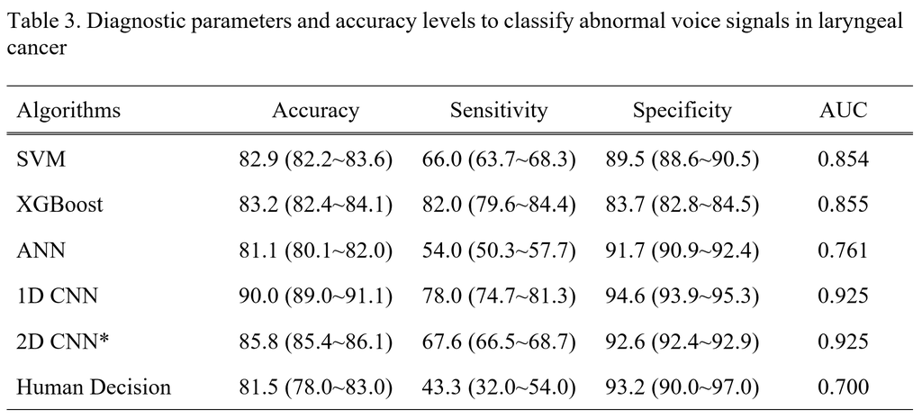

## 2.12. Auto Numbering

- numbering 이 필요한 그림, 테이블, 레퍼런스
- 자동으로 업데이트 되지 않으면
  - 예를 들어 새로운 그림이 윗 부분에 추가되면 모두 수정해야 하는 불편함이 생긴다.
- Ctrl + F9
  - {set name {seq fig}}
  - {ref name}
- 전체선택 (ctrl + A) $\rightarrow$ F9
  - 간혹 먼저 호출이 되고 아랫쪽에 정의가 되어 있을시에는 error 발생할 수 있다. 이때는 한번 더
  - 전체선택 (ctrl + A) $\rightarrow$ F9

## 2.13. Reference

- EndNote 를 사용해도 되고
  - 작성 후 꼭 살펴보기
  - 포멧이 틀려있는 것은 원본 파일 수정 필요
  - 논문을 정리할 때는 좋지만, 역시 워드에 삽일할 때는 위해서 설명한 numbering 기법이 더 편한 것 같다. (선택)
- 설명한 auto numbering 기법을 사용해도 된다.
- 형식은 반드시 통일
  - Et al. 등 수정 필요
  - Capitalization of word
- 본문에서 cite 를 할 때는 []

## 2.14. Review

- 협업을 할 때 중요하다
- New Comment
- Track Changes
- All Markup, Simple Markup
- Accept, Reject

## 2.15. Layout

- Layout $\rightarrow$ Size
- 영미권은 letter
  - 크게 중요하지 않지만, 논문 제출시 letter 로 제출
- 한국은 A4
- 만약 프린트를 한다면 용지 설정이 따로 필요할 수도 있음
- 또는 자동용지

## 2.16. PDF Converting

- Files $\rightarrow$Save As

# 3. PowerPoint

```python
%%html
<center><iframe src="https://www.youtube.com/embed/-xCzf42q9NY?rel=0"
width="560" height="315" frameborder="0" allowfullscreen></iframe></center>
```

[video not shown]

## 3.1. 철학적인 측면

- 문서 작업은 연구자로서 아주 중요
  - 연구를 잘 정리하는 것이 필요
  - 본인이 한 일을 잘 정리 할 뿐만 아니라 남이 이해할 수 있을 정도의 정리가 필요합니다.
  - 연구 또는 과제의 초기에는 기수행한 작업을 tracking 할 수 있지만, 많아지면 체계적인 문서정리 없이는 tracking 하기가 힘들어집니다.
  - 연구 50% + 문서작성 50% 의 비중으로 대학원 생활을 하도록.
  - 연구실 template를 사용하도록
    - MS word
    - PowerPoint
- 문서 작성을 잘 하기 위해서는
  - 기술적인 측면의 요령들을 익혀서 일단 작업이 익숙해져야 합니다. (예시, 단축키)
  - 기술적인 요령을 익히지 못해서 문서작업에 발못을 잡거나 느려지는 것은 피할 수 있도록.
  - 추후에는 깔끔하게 정리하는 것도 중요하지만, 더 중요한 것은 논리적 사고와 스토리를 어떻게 풀어 나가는지 고민하는 것이 가장 중요합니다
- 파워포인트의 역할
  - 발표 시 순서를 잡아준다
  - 말로 하기 힘든 부분을 설명하기 위해 도와주는 보조제
  - 모든 정보를 넣으면 오히려 전달이 힘들 수 있다.
    - 말로 할 부분과 파워포인트에 글과 그림으로 나타내야 하는 부분이 뭔지를 준비단계에서 고민
  - 발표 시 파워포인트를 보고 말하는 것이 아니라 청중을 보고 말을 해야 합니다.
    - 청중는 연사를 보지 않고 화면을 보고 있습니다.
  - 여러분이 학회나 랩미팅에서 다른 사람의 발표와 발표자료를 볼 때 어떻게 받아들이는지를 생각해보는 것이 여러분이 발표자료를 어떻게 준비해야하는지에 대한 가장 명확한 답이 될 수 있다.
  - 연사는 내용을 잘 알고 있지만, 청중은 수동적으로 앉아 있다고 가정하는 것이 현실적
  - 파워포인트를 보고서 역할로 사용할 때도 있다.
  - 주로 회사에서 이렇게 사용하며, 우리나라에서는 대부분의 파워포인트를 이렇게 인지
  - 이 경우에는 글이 많이 들어가고 슬라이드가 일반적으로 busy
    - 발표 시에는 추천하지 않습니다.
    - Busy 하면 눈에 안 들오는 경우가 많고, 대부분 이런 경우에 청중은 귀를 닫습니다.
  - 상황에 맞게 사용하면 됩니다.
- Slider Sorter 를 자주 사용하자
  - 전체적인 흐름을 보아야 한다
  - sub 주제가 있는 경우 특정 layout 사용
  - Add section

## 3.2. 기술적인 측면

- Title
  - 제목에 첫단어들은 대문자로 표시하자
    - must 는 아니지만 우리 연구실 약속
  - 같은 것으로 반복되면 안된다.
    - 피할 수 없다면 (1/2)
- Body
  - 문장으로 표현하는 것이 아니다.
    - e.g., There were no dramatic changes in the final heat map results. (X)
    - e.g., I think the performance depends on situation, not parameter. (X)
  - Hierarchical structure 가 가장 중요하다.
    - Parameters are eps and gamma. (X)
    - Hierarchical structure 에 레벨에 맞게 형식이 통일되는 것이 좋다
- Template
  - 기본 설정을 따로 건드리지 말고 사용
- Copy and Paste
  - 다양한 자료에서 일부를 가지고 올 때 format 도 따라온다.
    - Ctrl + C
    - Ctrl + V
  - paste 를 할때 format 없이 오게 할 수도 있지만,
  - 확실하게 하기 위해서 가장 선호하는 방법은 notepad 를 거쳐서 오는 것
  - 포멧 제거
    - Ctrl + Space
- Font 폰트
  - English
    - 무조건 Calibri 를 사용하도록
    - Text box 를 insert 할 때는 default 가 Arial 이지만 폰트를 수정할 수 있도록
  - 한글
    - 나눔고딕
    - https://hangeul.naver.com/font 에서 다운로드 받아서 설치해야 합니다. (무료)
    - File $\rightarrow$ Options
  - 폰트 크기 조절 단축키
    - Shift + Ctrl + <
    - Shift + Ctrl + >
  - 제목에서 한글 폰트를 하나 줄이는 것이 더 자연스럽다.
    - (이것은 우리 템플릿의 문제)
- 그림
  - 가능한 고해상도 그림 사용
  - 이동시에 arrow key 로 조정을 할 수 있다.
    - Ctrl + arrow key 를 더욱 미세한 조정이 가능하다.
  - Crop 기능을 잘 사용하도록
  - 비율을 그대로 유지
    - Shift
    - ctrl
  - 그림 복사하기
    - ctrl
  - 자동배치를 도와주는 붉은 점선을 최대한 활용하기
  - 여러 그림을 동시에 선택
  - right click → group
    - 협업 중에 누군가 편집이 필요한 경우에는 group 을 하지 않는 것이 도움
  - Home $\rightarrow$ Arrange $\rightarrow$ Align
  - 크기를 변경할때
    - 폰트 싸이즈가 달라질 수 있다
    - 그림 파일로 저장
  - 그림 연속
    - (페이지가 넘어갈 때 배치가 달라지는 것은 지양)
- 동영상
  - 동영상 용량 너무 크면 해상도를 낮추어서 임베딩
    - 프로젝터를 이용해 주로 발표하기 때문에 해상도가 낮아도 괜찮다.
  - 전체화면에서 자동 재생
    - (발표시에 마우스를 이용해서 play 하는 것은 발표를 매끄럽게 하지 못한다)
  - Animations $\rightarrow$ paly
  - 주로 mp4 동영상을 많이 사용하고 대부분 play 에 문제가 없지만,
  - 가끔 PowePoint 2010을 사용하는 컴퓨터에서는 play가 되지 않으니 주의
  - 동영상이 재생되지 않은면 발표가 unprofessional 하게 보임
    - 나도 이런 실수를 많이 함
  - 사전에 시스템을 점검하는 것이 꼭 필요
  - 동영상과 에니메이션이 없다면 pdf 로 준비하는 것이 가장 안전
- 소리
  - 소리가 중요한 발표 시에는 반드시 미리 점검하도록.
    - 사용하는 컴퓨터 세팅이 speaker off 로 되어 있는지 확인
  - HDMI 경우 소리까지 같이 케이블을 통해서 전달된다.
    - Select playback device
  - RGB 경우는 영상만
  - 세미나실에 전체 스피커에서 소리가 나면 가장 좋지만 그렇지 못한 경우는 노트북 스피커로 소리를 최대로 하면 대부분 크게 잘 들린다.
    - 이 소리도 작다고 느껴지면 사용하고 있는 마이크를 가까이 가져가면 된다.
- Slider Master
  - View $\rightarrow$ Slide Master
- 수식
  - 문장에 내에 있는 수식은 그냥 Insert → Equation 을 사용하자
    - (마음에 들지 않지만, 타협한 지점)
  - 수식이 단독으로 있는 경우는 jupyter notebook 으로 작성하고, 이를 html 로 변환후 크게 한 후 crop 해서 삽입
- 에니메이션
  - Animations $\rightarrow$ Animation Pane 을 사용할 것인지 슬라이드를 추가할 것인지 판단
  - 에니메이션을 잘 활용을 하면 청중의 시선과 페이스를 연사가 제어할 수 있다.
  - 하지만 너무 에니메이션이 많은 것은 피해야 한다.
  - 역시나 이 경우에도 어떻게 하면 내용을 잘 전달하는 방법이 무엇인지를 기준으로 에니메이션 적용
- Page Numbering
  - Insert $\rightarrow$ Header & Footer $\rightarrow$ Un-check ‘Slide number’ $\rightarrow$ Check ‘Slide number’ again
- PDF Converting
  - 외부로 자료를 전달할 때는 pdf 로
  - File $\rightarrow$ Save as

## 3.3. 발표

- Slide show from the first page: F5
- Slide show from the current page: Shift + F5
- 질문에서 페이지 수가 나오면, 페이지 수 누르고 Enter
- 발표자료를 충분히 화려하게 만들 수 있다. 하지만, 지금은 이런 기술적인 것이 전혀 중요하지 않고 기본에 충실하게 연습을 합시다.
- 스토리라인을 잘 짜고 이것을 도와주는 발표자료로 파워포인트를 생각하세요.
- 추후에 아주 중요한 발표자리라면 cosmetic 한 부분도 챙겨야 합니다.

```python
%%javascript
$.getScript('https://kmahelona.github.io/ipython_notebook_goodies/ipython_notebook_toc.js')
```